## Effect of climate change, mountain pine beetle, and forest fires on carbon cycling in whitebark pine (*Pinus albicus*) stands

### Setting up simple climate change simulation

Our model is focused on the Sierra Nevada Ecoregion. The following climate variables are from the Basin Characterization Model (Flint and Flint, 2014), and are based on statistically downscaled climate models for California. The were acquired from California Climate Commons.

```r
# Find average tmin and tmax values for Sierra Nevada Ecoregion based on historic data
cwd_raw = raster("../climate_data/cwd1981_2010_ave_HST_1559416632/cwd1981_2010_ave_HST_1559416632.tif")
snwpck_raw = raster("../climate_data/aprpck1981_2010_ave_HST_1559416720/aprpck1981_2010_ave_HST_1559416720.tif")
W_tmin_raw = raster("../climate_data/tmn1981_2010djf_ave_HST_1559415579/tmn1981_2010djf_ave_HST_1559415579.tif")
Su_tmax_raw = raster("../climate_data/tmx1981_2010jja_ave_HST_1559415851/tmx1981_2010jja_ave_HST_1559415851.tif")
sierra_nevada_outline = readOGR("../climate_data/SNC_Boundary_Shapefile/SNC_Boundary.shp") # Sierra Nevada ecoregion shapefile
```

### Business-as-usual Climate Change

Submodel 0 takes input climate data for historic climate variables, finds the mean, and then incrementally increases that value over a specified period of time.

```r
# Initialize climate change data.frame
clim_BAU = data.frame(year = 2010:2100)

# Fill in climate data table
clim_parms = list(total_change=-50,time=nrow(clim_BAU)) # April snowpack reduced by ~50%
clim_BAU$apr_snow = simulate_clim_chng_fun(snwpck_raw,crop_layer = sierra_nevada_outline,parms = clim_parms)

clim_parms = list(total_change=300,time=nrow(clim_BAU)) # CWD increases ~300 mm
clim_BAU$cwd = simulate_clim_chng_fun(cwd_raw,crop_layer = sierra_nevada_outline,parms = clim_parms)

clim_parms = list(total_change=10,time=nrow(clim_BAU)) # Winter minimum temp increases 10 degrees C
clim_BAU$W_tmin = simulate_clim_chng_fun(W_tmin_raw,crop_layer = sierra_nevada_outline,parms = clim_parms)

clim_parms = list(total_change=10,time=nrow(clim_BAU)) # Maximum summer temp increases 10 degrees C
clim_BAU$Su_tmax = simulate_clim_chng_fun(Su_tmax_raw,crop_layer = sierra_nevada_outline,parms = clim_parms)
```

The following code chunks use published whitebark pine vital rates, the simulated climate change dataframe, and our 5 submodels in a larger wrapper function. The output of the wrapper function is a large data.frame that shows main model inputs and outputs through time (2010 - 2100). Our model outputs are mountain pine beetle population size, pine population structure, total pine population, the probability and severity of a forest fire, and the pre- and post-fire carbon contained in the whitebark pine population. Subsequent code chunks show the following variations of this first scenario:

1. Business-as-usual climate change; Only beetles impact whitebark pines (output dataframe = “beetles_only”)
2. Business-as-usual climate change; Only climate impacts whitebark pines (output dataframe = “climate_only”)
3. Business-as-usual climate change; both beetles and climate impact whitebark pines (output dataframe = “beetles_and_climate”)
4. Moderate climate change; Only beetles impact whitebark pines (output dataframe = “beetles_only_mod”)
5. Moderate climate change; Only climate impacts whitebark pines (output dataframe = “climate_only_mod”)
6. Moderate climate change; both beetles and climate impact whitebark pines (output dataframe = “beetles_and_climate_mod”)

**1) Business-as-usual climate change; Only beetles impact whitebark pines (output dataframe = “beetles_only”)**

```r
impact_type = "beetles_only"
climate_chng_scen = "business-as-usual"

# Pine Fecundity
F0 = 0
F1 = 0
F2 = 0.0742
F3 = 0.2536
F4 = 1.6902

# Pine Survival
p0 = 0.9353
p1 = 0.9827
p2 = 0.9720
p3 = 0.9806
p4 = 0.9959

# Pine Growth
g01 = 0.0018
g12 = 0.0104
g23 = 0.0144
g34 = 0.0144

scenario_parms = list(years = length(clim_BAU),
                      time_step=2)

beetle_K = 20000
beetle_parms = list(btl_pop_0=5000,
                    r_max=1.16,
                    K_0_btl = 20000)

pine_parms = list(ntrees_0 = 1000,
                  initial_pop = c(100,100,50,50,50),
                  initial_carbon = 17884.34,
                  stages = c("<1cm","1-10cm","10-20cm","20-40cm",">40cm"),
                  avg_stage_dbh = c(1,5,15,30,50),
                  pine_fert = c(F0,F1,F2,F3,F4),
                  pine_surv = c(p0,p1,p2,p3,p4),
                  pine_growth = c(g01,g12,g23,g34))

beetles_only = whitePine_PopDynamics_model(clim_df = clim_BAU,
                                clim_scen_name = climate_chng_scen,
                                impact_type = impact_type,
                                scenario_parms = scenario_parms,
                                pine_parms = pine_parms,
                                beetle_parms = beetle_parms,
                                beetle_K = beetle_K)
```

**2) Business-as-usual climate change; Only climate impacts whitebark pines (output dataframe = “climate_only”)**

```r
impact_type = "climate_only"
climate_chng_scen = "business-as-usual"

# Pine Fecundity
F0 = 0
F1 = 0
F2 = 0.0742
F3 = 0.2536
F4 = 1.6902

# Pine Survival
p0 = 0.9353
p1 = 0.9827
p2 = 0.9720
p3 = 0.9806
p4 = 0.9959

# Pine Growth
g01 = 0.0018
g12 = 0.0104
g23 = 0.0144
g34 = 0.0144

scenario_parms = list(years = length(clim_BAU),
                      time_step=2)

beetle_K = 20000
beetle_parms = list(btl_pop_0=5000,
                    r_max=1.16,
                    K_0_btl = 20000)

pine_parms = list(ntrees_0 = 1000,
                  initial_pop = c(100,100,50,50,50),
                  initial_carbon = 17884.34,
                  stages = c("<1cm","1-10cm","10-20cm","20-40cm",">40cm"),
                  avg_stage_dbh = c(1,5,15,30,50),
                  pine_fert = c(F0,F1,F2,F3,F4),
                  pine_surv = c(p0,p1,p2,p3,p4),
                  pine_growth = c(g01,g12,g23,g34))

climate_only = whitePine_PopDynamics_model(clim_df = clim_BAU,
                                clim_scen_name = climate_chng_scen,
                                impact_type = impact_type,
                                scenario_parms = scenario_parms,
                                pine_parms = pine_parms,
                                beetle_parms = beetle_parms,
                                beetle_K = beetle_K)
```

**3) Business-as-usual climate change; both beetles and climate impact whitebark pines (output dataframe = “beetles_and_climate”)**

```r
impact_type = "beetles_and_climate"
climate_chng_scen = "business-as-usual"

# Pine Fecundity
F0 = 0
F1 = 0
F2 = 0.0742
F3 = 0.2536
F4 = 1.6902

# Pine Survival
p0 = 0.9353
p1 = 0.9827
p2 = 0.9720
p3 = 0.9806
p4 = 0.9959

# Pine Growth
g01 = 0.0018
g12 = 0.0104
g23 = 0.0144
g34 = 0.0144

scenario_parms = list(years = length(clim_BAU),
                      time_step=2)

beetle_K = 20000
beetle_parms = list(btl_pop_0=5000,
                    r_max=1.16,
                    K_0_btl = 20000)

pine_parms = list(ntrees_0 = 1000,
                  initial_pop = c(100,100,50,50,50),
                  initial_carbon = 17884.34,
                  stages = c("<1cm","1-10cm","10-20cm","20-40cm",">40cm"),
                  avg_stage_dbh = c(1,5,15,30,50),
                  pine_fert = c(F0,F1,F2,F3,F4),
                  pine_surv = c(p0,p1,p2,p3,p4),
                  pine_growth = c(g01,g12,g23,g34))

beetles_and_climate = whitePine_PopDynamics_model(clim_df = clim_BAU,
                                clim_scen_name = climate_chng_scen,
                                impact_type = impact_type,
                                scenario_parms = scenario_parms,
                                pine_parms = pine_parms,
                                beetle_parms = beetle_parms,
                                beetle_K = beetle_K)
```

### Moderate climate change scenario

```r
### Find historic averages for climate variables of interest and then create a theoretical climate change scenario based on those averages and expected change
years = 91
clim_moderate = data.frame(year = 2010:2100)

# Fill in climate data table
clim_parms = list(total_change=-25,time=years) # April snowpack is reduced by about 25%
clim_moderate$apr_snow = simulate_clim_chng_fun(snwpck_raw,crop_layer = sierra_nevada_outline,parms = clim_parms)

clim_parms = list(total_change=150,time=years) # CWW increases by 150 mm
clim_moderate$cwd = simulate_clim_chng_fun(cwd_raw,crop_layer = sierra_nevada_outline,parms = clim_parms)

clim_parms = list(total_change=5,time=years) # Minimum Winter Temperature increases by 5 degrees C
clim_moderate$W_tmin = simulate_clim_chng_fun(W_tmin_raw,crop_layer = sierra_nevada_outline,parms = clim_parms)

clim_parms = list(total_change=5,time=years) # Maximum Summer Temperature increases by 5 degrees C
clim_moderate$Su_tmax = simulate_clim_chng_fun(Su_tmax_raw,crop_layer = sierra_nevada_outline,parms = clim_parms)
```

```r
impact_type = "beetles_only"
climate_chng_scen = "moderate"

# Pine Fecundity
F0 = 0
F1 = 0
F2 = 0.0742
F3 = 0.2536
F4 = 1.6902

# Pine Survival
p0 = 0.9353
p1 = 0.9827
p2 = 0.9720
p3 = 0.9806
p4 = 0.9959

# Pine Growth
g01 = 0.0018
g12 = 0.0104
g23 = 0.0144
g34 = 0.0144

beetle_K = 20000
scenario_parms = list(years = length(clim_moderate),
                      time_step=2)

beetle_K = 20000
beetle_parms = list(btl_pop_0=5000,
                    r_max=1.16,
                    K_0_btl = beetle_K)

pine_parms = list(ntrees_0 = 1000,
                  initial_pop = c(100,100,50,50,50),
                  initial_carbon = 17884.34,
                  stages = c("<1cm","1-10cm","10-20cm","20-40cm",">40cm"),
                  avg_stage_dbh = c(1,5,15,30,50),
                  pine_fert = c(F0,F1,F2,F3,F4),
                  pine_surv = c(p0,p1,p2,p3,p4),
                  pine_growth = c(g01,g12,g23,g34))

beetles_only_mod = whitePine_PopDynamics_model(clim_df = clim_moderate,
                                clim_scen_name = climate_chng_scen,
                                impact_type = impact_type,
                                scenario_parms = scenario_parms,
                                pine_parms = pine_parms,
                                beetle_parms = beetle_parms,
                                beetle_K = beetle_K)
```

```r
impact_type = "climate_only"
climate_chng_scen = "moderate"

# Pine Fecundity
F0 = 0
F1 = 0
F2 = 0.0742
F3 = 0.2536
F4 = 1.6902

# Pine Survival
p0 = 0.9353
p1 = 0.9827
p2 = 0.9720
p3 = 0.9806
p4 = 0.9959

# Pine Growth
g01 = 0.0018
g12 = 0.0104
g23 = 0.0144
g34 = 0.0144

scenario_parms = list(years = length(clim_moderate),
                      time_step=2)

beetle_K = 20000
beetle_parms = list(btl_pop_0=5000,
                    r_max=1.16,
                    K_0_btl = 20000)

pine_parms = list(ntrees_0 = 1000,
                  initial_pop = c(100,100,50,50,50),
                  initial_carbon = 17884.34,
                  stages = c("<1cm","1-10cm","10-20cm","20-40cm",">40cm"),
                  avg_stage_dbh = c(1,5,15,30,50),
                  pine_fert = c(F0,F1,F2,F3,F4),
                  pine_surv = c(p0,p1,p2,p3,p4),
                  pine_growth = c(g01,g12,g23,g34))

climate_only_mod = whitePine_PopDynamics_model(clim_df = clim_moderate,
                                clim_scen_name = climate_chng_scen,
                                impact_type = impact_type,
                                scenario_parms = scenario_parms,
                                pine_parms = pine_parms,
                                beetle_parms = beetle_parms,
                                beetle_K = beetle_K)
```

```r
impact_type = "beetles_and_climate"
climate_chng_scen = "moderate"

# Pine Fecundity
F0 = 0
F1 = 0
F2 = 0.0742
F3 = 0.2536
F4 = 1.6902

# Pine Survival
p0 = 0.9353
p1 = 0.9827
p2 = 0.9720
p3 = 0.9806
p4 = 0.9959

# Pine Growth
g01 = 0.0018
g12 = 0.0104
g23 = 0.0144
g34 = 0.0144

scenario_parms = list(years = length(clim_moderate),
                      time_step=2)

beetle_K = 20000
beetle_parms = list(btl_pop_0=5000,
                    r_max=1.16,
                    K_0_btl = 20000)

pine_parms = list(ntrees_0 = 1000,
                  initial_pop = c(100,100,50,50,50),
                  initial_carbon = 17884.34,
                  stages = c("<1cm","1-10cm","10-20cm","20-40cm",">40cm"),
                  avg_stage_dbh = c(1,5,15,30,50),
                  pine_fert = c(F0,F1,F2,F3,F4),
                  pine_surv = c(p0,p1,p2,p3,p4),
                  pine_growth = c(g01,g12,g23,g34))

beetles_and_climate_mod = whitePine_PopDynamics_model(clim_df = clim_moderate,
                                clim_scen_name = climate_chng_scen,
                                impact_type = impact_type,
                                scenario_parms = scenario_parms,
                                pine_parms = pine_parms,
                                beetle_parms = beetle_parms,
                                beetle_K = beetle_K)
```

## Graph Results:

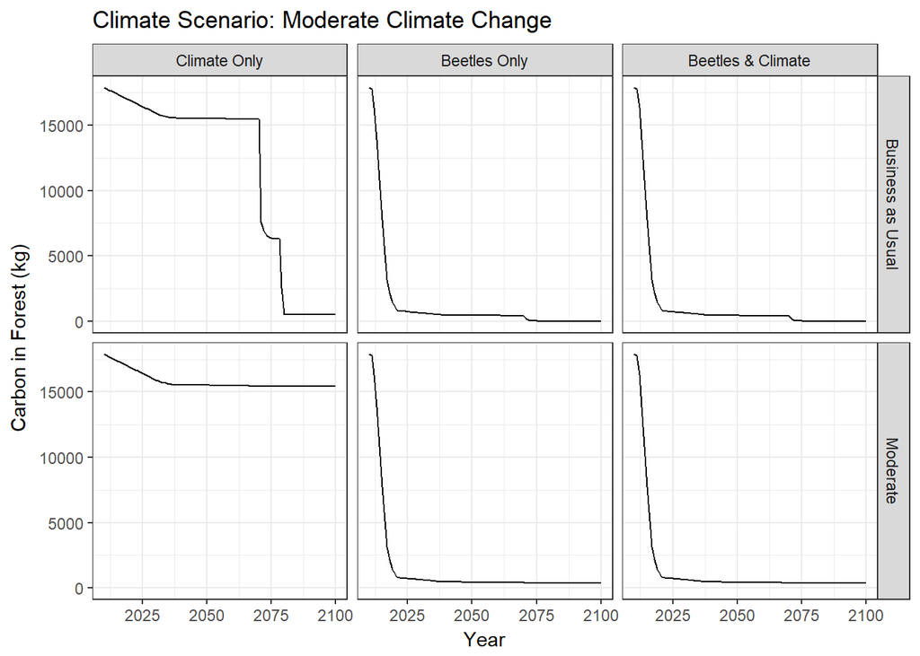

```r
scenario_df = rbind.data.frame(climate_only, beetles_only, beetles_and_climate,
                               climate_only_mod, beetles_only_mod, beetles_and_climate_mod)

impact_labels = c(climate_only = "Climate Only", beetles_only = "Beetles Only", beetles_and_climate = "Beetles & Climate")
climate_labels = c('business-as-usual' = "Business as Usual", 'moderate' = "Moderate")

ggplot(scenario_df, aes(x = year, y = postFire_forest_carbon, by = impact_type))+
  facet_grid(climate ~ impact_type, labeller = labeller(impact_type = impact_labels, climate = climate_labels))+
  geom_line()+
  xlab("Year")+
  ylab("Carbon in Forest (kg)")+
  ggtitle("Climate Scenario: Moderate Climate Change")+
  theme_bw()
```

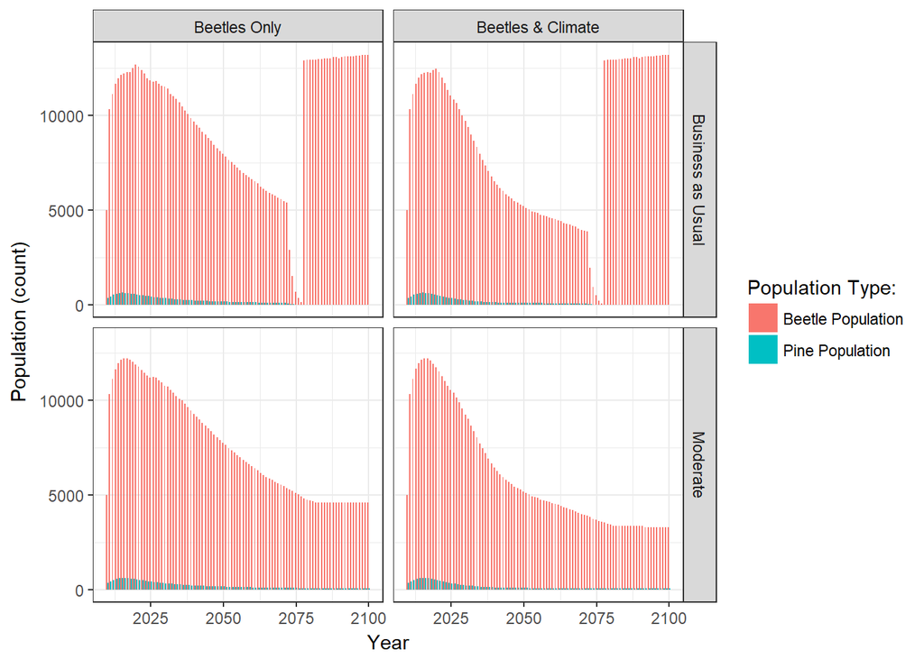

```r
# Comparison of total beetle and total pine populations

beetle_df = subset.data.frame(x = scenario_df, select = c(year, total_pine, btl_pop, impact_type, climate))

beetle_df = filter(beetle_df, impact_type == "beetles_only" | impact_type == "beetles_and_climate")

beetle_long_df = gather(data = beetle_df, key = pop_type, value = pop_amt,
                        total_pine:btl_pop)

ggplot(beetle_long_df, aes(x = year, y = pop_amt, fill = pop_type))+
  facet_grid(climate ~ impact_type, labeller = labeller(impact_type = impact_labels, climate = climate_labels))+
  geom_bar(stat = "identity", position = position_dodge())+
  ylab("Population (count)")+
  xlab("Year")+
  scale_fill_discrete(name = "Population Type:", labels = c("Beetle Population", "Pine Population"))+
  theme_bw()
```

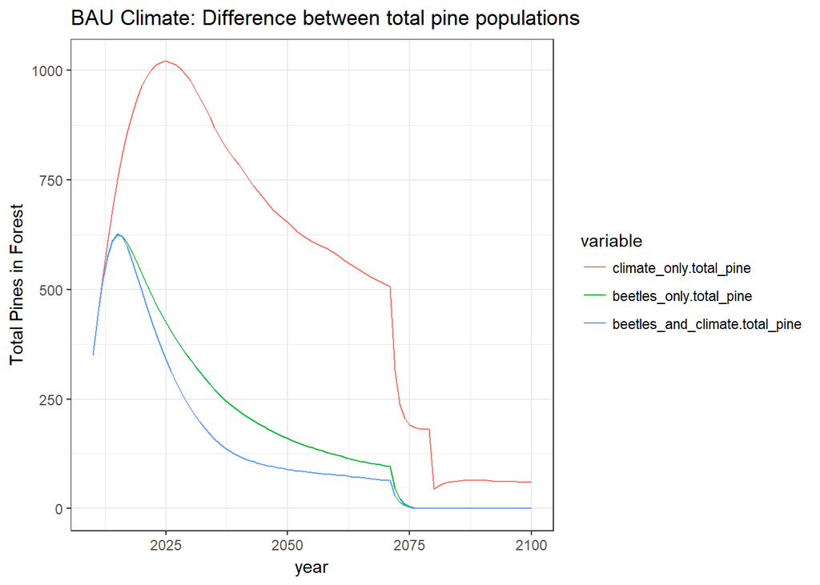

```r
#Investigating differences between total pine populations and each scenario

diffs_BAU = data.frame(year = climate_only$year,
                    climate_only$total_pine,
                    beetles_only$total_pine,
                    beetles_and_climate$total_pine) %>%
  melt(id.vars = "year")

diffs_moderate = data.frame(year = climate_only$year,
                    "climate only" = climate_only_mod$total_pine,
                    "beetles only" = beetles_only_mod$total_pine,
                    beetles_and_climate_mod$total_pine) %>%
  melt(id.vars = "year")

ggplot(diffs_BAU,aes(x = year, y = value, color = variable))+
  geom_line()+
  theme_bw()+
  ggtitle("BAU Climate: Difference between total pine populations")+
  ylab("Total Pines in Forest")
```

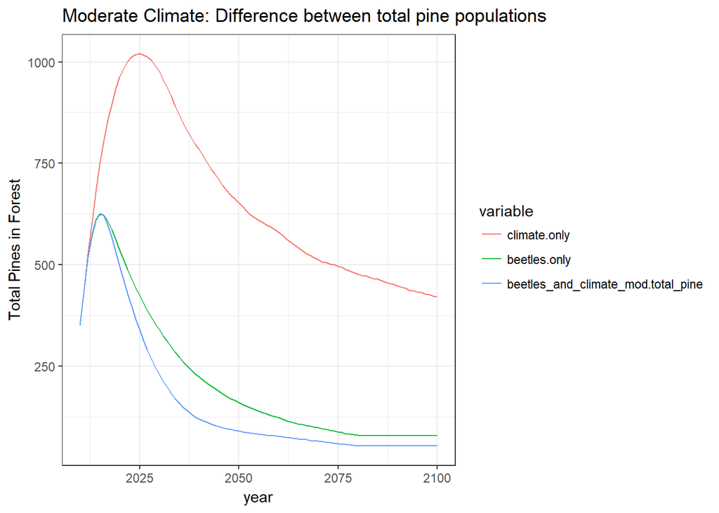

```r
ggplot(diffs_moderate,aes(x = year, y = value, color = variable))+
  geom_line()+
  theme_bw()+
  ggtitle("Moderate Climate: Difference between total pine populations")+
  ylab("Total Pines in Forest")
```